# Genus Assertion

Robin von Allmen

18 3 2021

## Preparing Data

First we read in the Data of our 10 samples of our Fossil to create a procrustes fit, from which we then create the “Mean Shape” of our specimen to rule out the effects of perspective on the picture from the CT-Scan.

```r
landmark = readland.tps("FOSSIL_R.TPS",specID = "ID", readcurves = T, warnmsg = TRUE)


##      define Semilandmarks, first LM is the start, last one the end (those are both
##      fixed landmarks, in between are the semilandmarks):
sliders = define.sliders(c(15,22:29,16))

##      procrustes fit - "superimposition" - rotates and scales the landmarks to their closest distance,
##      minimizing the shape and size difference:
proD<-gpagen(landmark, surfaces = NULL, curves = sliders,
             PrinAxes = FALSE, max.iter = NULL, ProcD = T, Proj = TRUE,
             print.progress = TRUE)
```

## PCA Analysis

We can look at the PCA for a second, however eventhough these are Data of the very same data, the variation may be huge, since the variation will be scaled depending on how equal they are. So if we would put all the other Data in this plot as well these points would relatively be closer together.

```r
PCA1 <-plotTangentSpace(proD$coords)
```

[output not shown]

```r
dev.off()
```

Now we create our Mean shape for our specimen and load the other data which we append our fossil later.

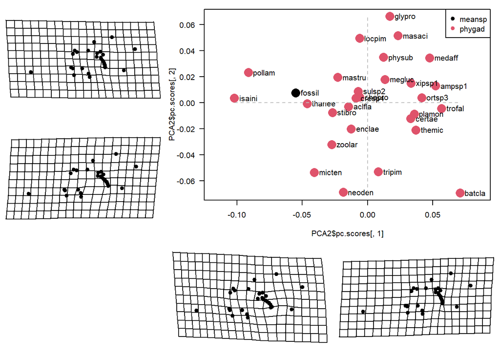

```r
#consesus Data from the proD contains the mean points for the procrustes fit of the fossil versions.
meanfossil <- array(proD$consensus,dim= c(29,2,1))
#change the name of the 3rd row so that we can later label our fossil specifically.
dimnames(meanfossil)[[3]] <- "fossil_meansp_g.JPG"

landmarkphygad = readland.tps("PHYGAD2.TPS",specID = "ID", readcurves = T, warnmsg = TRUE)
landmarkphygad2 = readland.tps("DATASET_PHYGAD.TPS",specID = "ID", readcurves = T, warnmsg = TRUE)

landmark <- Abind(landmarkphygad,meanfossil,landmarkphygad2)

species = as.factor( substr( dimnames(landmark)[[3]], 1, 6))
subfam = as.factor( substr( dimnames(landmark)[[3]], 8, 13))
areolet = as.factor( substr( dimnames(landmark)[[3]], 15, 15))


##      define Semilandmarks, first LM is the start, last one the end (those are both
##      fixed landmarks, in between are the semilandmarks):
sliders = define.sliders(c(15,22:29,16))

##      procrustes fit - "superimposition" - rotates and scales the landmarks to their closest distance,
##      minimizing the shape and size difference:
proD<-gpagen(landmark, surfaces = NULL, curves = sliders,
             PrinAxes = FALSE, max.iter = NULL, ProcD = T, Proj = TRUE,
             print.progress = TRUE)

PCA2 <-plotTangentSpace(proD$coords, groups=subfam, legend=T)
```

In this plot we clearly see that there is also variance in between our Phygadeuontinae and that our specimen does cluster with some other specimen. (especially with thanee, but as we will see in our Dendrogramm, their phenetic relationship is not as close. This is due to the fact that in a PCA-Plot we only see two scores and in the dendrogram we use Procrustes Distances instead).

## Clustering in new Taxonomy and Dendrogram

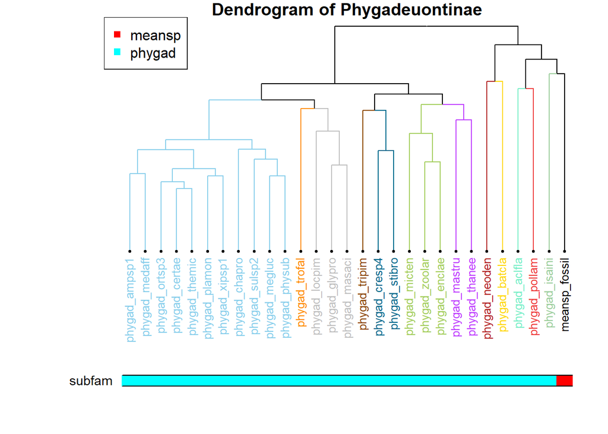

```r
# Compute distances and hierarchical clustering
dd <- dist(scale(Proc_dist))

## Ward's minimum variance method
hc <- hclust(dd, method = "average")

hc$labels = row.names(Proc_dist)

# Convert hclust into a dendrogram and plot
hcd <- as.dendrogram(hc)

require("dendextend") ## needs a dendrogram
#plot(hcd)

# Create a vector of colors, darkgreen if am is 0, green if 1.
my_colors <- ifelse(substr(hc$labels, 1, 6)=="phygad", "cyan", "red")


par(mar=c(10,6,1,1))
hcd %>%
  set("labels_col", value = c("skyblue", "darkorange", "grey","darkorange4","deepskyblue4",
                              "darkolivegreen3","darkorchid1","firebrick","gold1","aquamarine2","brown2","darkseagreen3","black"), k=13) %>%
  set("branches_k_color", value = c("skyblue", "darkorange", "grey","darkorange4","deepskyblue4",
                                    "darkolivegreen3","darkorchid1","firebrick","gold1","aquamarine2","brown2","darkseagreen3","black"),k = 13) %>%
  set("labels_cex", 0.8)  %>%
  set("leaves_pch", 19)  %>%
  set("nodes_cex", 0.4) %>%

  plot(axes=FALSE)

# Add the colored bar
colored_bars(colors = my_colors, dend = hcd, rowLabels = "subfam")
legend("topleft", legend=levels(subfam), col= c("red", "cyan"), pch=15)
title(main= "Dendrogram of Phygadeuontinae")
```

Interestingly in this dendrogram our fossil clusters with isaini (Isadelphus inimicus) and other specimen which are present in scandinavia, which is thought to be the origin of Baltic Amber.